## Binary Logistic Regression Case Study: Marketing Campaign Response Model

### Background: The large skin-clinic in the city of “XXX” offers variety of products and services to customers. The marketing campaign was launched for introducing a new product.

### The data shows response to the marketing campaign alongwith demographic and transaction data of customers.

### The objective is to identify factors driving response to the marketing campaign.

#### Import datasets and create masterdata

```r
purchase_data1<-read.csv("Purchase Data 1.csv",header=T)
purchase_data2<-read.csv("Purchase Data 2.csv",header=T)
response_data<-read.csv("Response Data.csv",header=T)
library(dplyr)

masterdata<-Reduce(function(dtf1, dtf2) merge(dtf1, dtf2, by = "Custid", all.x = TRUE),
       list(response_data,purchase_data1,purchase_data2))
```

#### Convert numerically coded categorical variables into “factors”

```r
masterdata$Age<-as.factor(masterdata$Age)
masterdata$Gender<-as.factor(masterdata$Gender)
masterdata$MS<-as.factor(masterdata$MS)
masterdata$Pre_Month<-as.factor(masterdata$Pre_Month)
```

#### Display first 6 rows

```r
head(masterdata)
```

```
  Custid Age Gender MS Response Pre_Month N_Products N_Service BillAmt_1
1      1   2      1  2        1         2         15        24     12.34
2      2   2      2  1        0         1         22        29     18.65
3      3   1      1  2        0         1         17        21      7.22
4      4   2      1  1        0         2         18        22      6.15
5      5   2      2  1        0         1         31        35     20.64
6      6   1      2  1        0         2         28        31     12.44
  BillAmt_2 BillAmt_3
1     13.26      5.88
2      2.12      5.13
3      3.31      3.65
4      2.95      2.34
5      2.67      4.07
6      3.06      2.57
```

#### Data Description

| Column name | Column desciption |
| --- | --- |
| Custid | Customer Identification Code |
| Age | Age group(1:<32,2:32-48,3:>48) |
| Gender | Gender(1:Female,2:Male) |
| MS | Marital Status(1: Not Married,2:Married) |
| BillAmt_1.BillAmt_2.BillAmt_3 | Bill Amounts (USD) for Last Three Purchases |
| Pre_Month | Purchase in Previous Week(1: Purchased in Previous Week,2: No purchase in Previous Week) |
| N_Products | Number of unique products purchased in One Year |
| N_Service | Number of unique services purchased in one year |

#### Check Campaign Response Rate

```r
library(gmodels)
CrossTable(masterdata$Response)
```

```
   Cell Contents
|-------------------------|
|                       N |
|         N / Table Total |
|-------------------------|


Total Observations in Table:  6990


          |         0 |         1 |
          |-----------|-----------|
          |      6065 |       925 |
          |     0.868 |     0.132 |
          |-----------|-----------|
```

#### Comment: Approximately 13% of customers responded positively to the campaign

#### Table of summary statistics for bill amount 1,2,3 by aggregate and dplyr

```r
f <- function(x) {
    c(count = length(x),
    mean = mean(x),
    median = median(x),
    sd = sd(x))
}

summary_stats_BillAmt_1 <- aggregate(BillAmt_1 ~ Response, data=masterdata, FUN=f)
summary_stats_BillAmt_1
```

```
  Response BillAmt_1.count BillAmt_1.mean BillAmt_1.median BillAmt_1.sd
1        0     6065.000000      12.342041        10.770000     6.940059
2        1      925.000000      15.473643        15.210000     6.677068
```

```r
summary_stats_BillAmt_2 <- aggregate(BillAmt_2 ~ Response, data=masterdata, FUN=f)
summary_stats_BillAmt_2
```

```
  Response BillAmt_2.count BillAmt_2.mean BillAmt_2.median BillAmt_2.sd
1        0     6065.000000       2.987598         2.590000     2.268582
2        1      925.000000       3.365081         2.990000     2.348871
```

```r
summary_stats_BillAmt_3 <- aggregate(BillAmt_3 ~ Response, data=masterdata, FUN=f)
summary_stats_BillAmt_3
```

```
  Response BillAmt_3.count BillAmt_3.mean BillAmt_3.median BillAmt_3.sd
1        0     6065.000000       4.035880         3.000000     3.320684
2        1      925.000000       4.194768         3.200000     3.456211
```

```r
library(dplyr)
masterdata %>%
  group_by(Response) %>%
  summarise(n=length(BillAmt_1),
    mean = mean(BillAmt_1),
    median = median(BillAmt_1),
    sd = sd(BillAmt_1)) %>%
  as.data.frame()
```

```
  Response    n     mean median       sd
1        0 6065 12.34204  10.77 6.940059
2        1  925 15.47364  15.21 6.677068
```

```r
masterdata %>%
  group_by(Response) %>%
  summarise(n=length(BillAmt_2),
            mean = mean(BillAmt_2),
            median = median(BillAmt_2),
            sd = sd(BillAmt_2))%>%
  as.data.frame()
```

```
  Response    n     mean median       sd
1        0 6065 2.987598   2.59 2.268582
2        1  925 3.365081   2.99 2.348871
```

```r
masterdata %>%
  group_by(Response) %>%
  summarise(n=length(BillAmt_3),
            mean = mean(BillAmt_3),
            median = median(BillAmt_3),
            sd = sd(BillAmt_3))%>%
  as.data.frame()
```

```
  Response    n     mean median       sd
1        0 6065 4.035880    3.0 3.320684
2        1  925 4.194768    3.2 3.456211
```

#### Comment: Higher bill amounts(average) in last 3 transactions are observed for customers with positive response

#### Box plot of N_products and N_service by Response

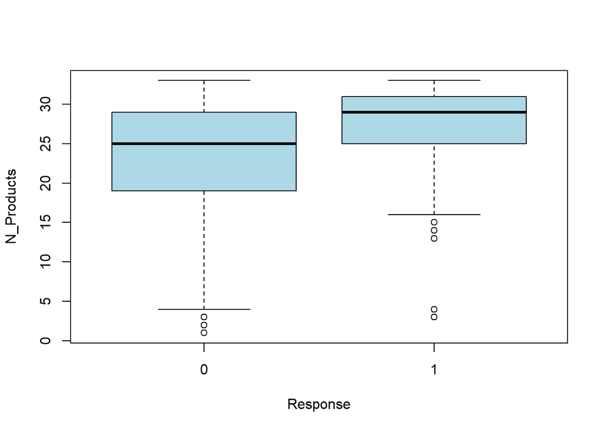

```r
boxplot(N_Products~Response,data=masterdata,col = "lightblue")
```

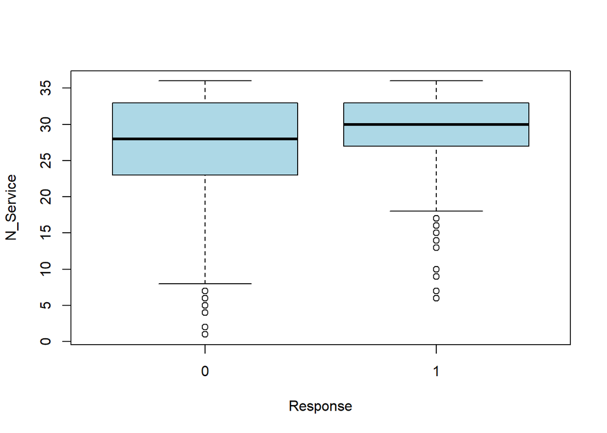

```r
boxplot(N_Service~Response,data=masterdata,col = "lightblue")
```

#### More products and services are purchased by customers with positive resposne

#### Cross tab for Gender vs Response

```r
library(gmodels)
CrossTable(masterdata$Gender,masterdata$Response,prop.r = TRUE,prop.c = F)
```

```
   Cell Contents
|-------------------------|
|                       N |
| Chi-square contribution |
|           N / Row Total |
|         N / Table Total |
|-------------------------|


Total Observations in Table:  6990


                  | masterdata$Response
masterdata$Gender |         0 |         1 | Row Total |
------------------|-----------|-----------|-----------|
                1 |      3054 |       448 |      3502 |
                  |     0.078 |     0.514 |           |
                  |     0.872 |     0.128 |     0.501 |
                  |     0.437 |     0.064 |           |
------------------|-----------|-----------|-----------|
                2 |      3011 |       477 |      3488 |
                  |     0.079 |     0.516 |           |
                  |     0.863 |     0.137 |     0.499 |
                  |     0.431 |     0.068 |           |
------------------|-----------|-----------|-----------|
     Column Total |      6065 |       925 |      6990 |
------------------|-----------|-----------|-----------|
```

#### Develop Campaign Response Model using Binary Logistic Regression

#### Split original data into training and testing data sets

```r
library(caret)
masterdata$Response<-as.factor(masterdata$Response)
index<-createDataPartition(masterdata$Response,p=0.7,list=FALSE)
traindata<-masterdata[index,]
testdata<-masterdata[-index,]
```

#### Binary Logistic Regression using glm function

```r
blr_model<-glm(Response~Age+Gender+MS+Pre_Month+N_Products+N_Service+BillAmt_1+BillAmt_2+BillAmt_3,
                   data=traindata,family = binomial)
```

#### Display parameter estimates with other model statistics

```r
summary(blr_model)
```

```
Call:
glm(formula = Response ~ Age + Gender + MS + Pre_Month + N_Products +
    N_Service + BillAmt_1 + BillAmt_2 + BillAmt_3, family = binomial,
    data = traindata)

Deviance Residuals:
    Min       1Q   Median       3Q      Max
-1.5854  -0.5876  -0.4001  -0.2195   2.6778

Coefficients:
             Estimate Std. Error z value Pr(>|z|)
(Intercept) -7.786534   0.398695 -19.530  < 2e-16 ***
Age2        -0.243687   0.108734  -2.241    0.025 *
Age3        -0.094811   0.107105  -0.885    0.376
Gender2      0.006044   0.088912   0.068    0.946
MS2         -0.084680   0.088957  -0.952    0.341
Pre_Month2   0.016065   0.088971   0.181    0.857
N_Products   0.152382   0.010600  14.375  < 2e-16 ***
N_Service    0.034020   0.007858   4.329 1.50e-05 ***
BillAmt_1    0.037330   0.007543   4.949 7.46e-07 ***
BillAmt_2    0.181133   0.025150   7.202 5.93e-13 ***
BillAmt_3    0.016312   0.018873   0.864    0.387
---
Signif. codes:  0 '***' 0.001 '**' 0.01 '*' 0.05 '.' 0.1 ' ' 1

(Dispersion parameter for binomial family taken to be 1)

    Null deviance: 3826.5  on 4893  degrees of freedom
Residual deviance: 3366.9  on 4883  degrees of freedom
AIC: 3388.9

Number of Fisher Scoring iterations: 6
```

#### Comment: “Gender”,“MS”,“Pre_Month” and “BillAmt_3” are the insignificant variables.

#### Rerun the model after removing the insignificant variables

```r
blr_model<-glm(Response~Age+N_Products+N_Service+BillAmt_1+BillAmt_2,
                   data=traindata,family = binomial)
summary(blr_model)
```

```
Call:
glm(formula = Response ~ Age + N_Products + N_Service + BillAmt_1 +
    BillAmt_2, family = binomial, data = traindata)

Deviance Residuals:
    Min       1Q   Median       3Q      Max
-1.6168  -0.5865  -0.3997  -0.2200   2.6505

Coefficients:
             Estimate Std. Error z value Pr(>|z|)
(Intercept) -7.726857   0.378703 -20.403  < 2e-16 ***
Age2        -0.243020   0.108630  -2.237   0.0253 *
Age3        -0.095974   0.107034  -0.897   0.3699
N_Products   0.149944   0.010246  14.634  < 2e-16 ***
N_Service    0.033186   0.007787   4.262 2.03e-05 ***
BillAmt_1    0.040348   0.006784   5.948 2.72e-09 ***
BillAmt_2    0.188012   0.023701   7.933 2.15e-15 ***
---
Signif. codes:  0 '***' 0.001 '**' 0.01 '*' 0.05 '.' 0.1 ' ' 1

(Dispersion parameter for binomial family taken to be 1)

    Null deviance: 3826.5  on 4893  degrees of freedom
Residual deviance: 3368.6  on 4887  degrees of freedom
AIC: 3382.6

Number of Fisher Scoring iterations: 6
```

#### Comment: 4 out of 5 significant purchase related variables have positive regression coefficients while Age variable has negative regression coefficient. Higher values are associated with positive campaign response.

#### Check for multicollinearity using vif function

```r
library(car)
vif(blr_model)
```

```
               GVIF Df GVIF^(1/(2*Df))
Age        1.001625  2        1.000406
N_Products 1.376645  1        1.173305
N_Service  1.091731  1        1.044860
BillAmt_1  1.312614  1        1.145694
BillAmt_2  1.758665  1        1.326146
```

#### Comment: It is observed that no variable has high vif

#### Hence the problem of multicollinearity does not exist

#### Evaluate model performance by ROC Curve using ROCR package

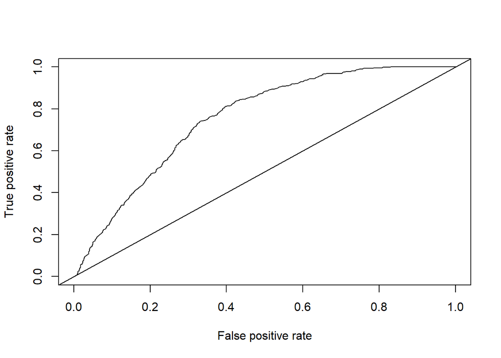

```r
library(ROCR)
traindata$predprob<-fitted(blr_model)
predtrain<-prediction(traindata$predprob,traindata$Response)
perftrain<-performance(predtrain,"tpr","fpr")
plot(perftrain)
abline(0,1)
```

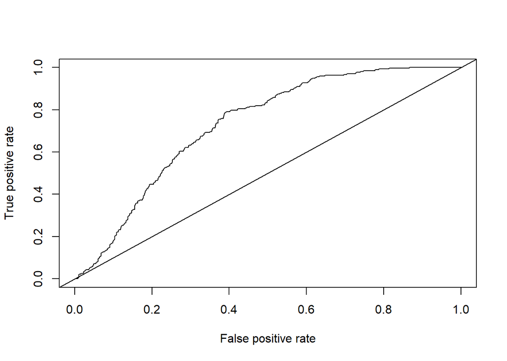

```r
testdata$predprob<-predict(blr_model,testdata,type='response')
predtest<-prediction(testdata$predprob,testdata$Response)
perftest<-performance(predtest,"tpr","fpr")
plot(perftest)
abline(0,1)
```

#### Checking area under the ROC curve

```r
auctrain<-performance(predtrain,"auc")
auctrain@y.values
```

```
[[1]]
[1] 0.7551839
```

```r
auctest<-performance(predtest,"auc")
auctest@y.values
```

```
[[1]]
[1] 0.7291883
```

#### Model Validation: Holdout Method using confusionMatrix

#### Finding optimum threshold for classification by maximizing sensitivity + specificity

```r
sstrain <- performance(predtrain, "sens", "spec")
best_threshold <- sstrain@alpha.values[[1]][which.max(sstrain@x.values[[1]]+sstrain@y.values[[1]])]
best_threshold
```

```
[1] 0.1209881
```

#### Confusion matrix for train and test data

```r
traindata$predY<-as.factor(ifelse(traindata$predprob>best_threshold,1,0))
confusionMatrix(traindata$predY,traindata$Response,positive="1")
```

```
Confusion Matrix and Statistics

          Reference
Prediction    0    1
         0 2561  123
         1 1685  525

               Accuracy : 0.6306
                 95% CI : (0.6169, 0.6441)
    No Information Rate : 0.8676
    P-Value [Acc > NIR] : 1

                  Kappa : 0.2045

 Mcnemar's Test P-Value : <2e-16

            Sensitivity : 0.8102
            Specificity : 0.6032
         Pos Pred Value : 0.2376
         Neg Pred Value : 0.9542
             Prevalence : 0.1324
         Detection Rate : 0.1073
   Detection Prevalence : 0.4516
      Balanced Accuracy : 0.7067

       'Positive' Class : 1
```

```r
testdata$predY<-as.factor(ifelse(testdata$predprob>best_threshold,1,0))
confusionMatrix(testdata$predY,testdata$Response,positive="1")
```

```
Confusion Matrix and Statistics

          Reference
Prediction    0    1
         0 1020   54
         1  799  223

               Accuracy : 0.593
                 95% CI : (0.5716, 0.6142)
    No Information Rate : 0.8678
    P-Value [Acc > NIR] : 1

                  Kappa : 0.1709

 Mcnemar's Test P-Value : <2e-16

            Sensitivity : 0.8051
            Specificity : 0.5607
         Pos Pred Value : 0.2182
         Neg Pred Value : 0.9497
             Prevalence : 0.1322
         Detection Rate : 0.1064
   Detection Prevalence : 0.4876
      Balanced Accuracy : 0.6829

       'Positive' Class : 1
```

#### K-fold cross validation using caret package

```r
library(caret)
kfolds<-trainControl(method="cv",number=4)
kmodel<-train(Response~N_Products+N_Service+BillAmt_1+BillAmt_2,data=traindata,method="glm",
        family=binomial,trControl=kfolds)

kmodel
```

```
Generalized Linear Model

4894 samples
   4 predictor
   2 classes: '0', '1'

No pre-processing
Resampling: Cross-Validated (4 fold)
Summary of sample sizes: 3671, 3671, 3670, 3670
Resampling results:

  Accuracy   Kappa
  0.8624844  0.00769249
```

```r
traindata$pred <- kmodel$finalModel$fitted.values
traindata$predY <-as.factor(ifelse(traindata$pred > best_threshold , 1,0))
confusionMatrix(traindata$predY,traindata$Response,positive="1")
```

```
Confusion Matrix and Statistics

          Reference
Prediction    0    1
         0 2554  124
         1 1692  524

               Accuracy : 0.6289
                 95% CI : (0.6152, 0.6425)
    No Information Rate : 0.8676
    P-Value [Acc > NIR] : 1

                  Kappa : 0.2025

 Mcnemar's Test P-Value : <2e-16

            Sensitivity : 0.8086
            Specificity : 0.6015
         Pos Pred Value : 0.2365
         Neg Pred Value : 0.9537
             Prevalence : 0.1324
         Detection Rate : 0.1071
   Detection Prevalence : 0.4528
      Balanced Accuracy : 0.7051

       'Positive' Class : 1
```

#### Comment: The Area Under ROC Curve (AUC) for train and test data indicate that the model is stable and performed well on test data. The sensitivity value using optimum threshold is 80% for test data. There is a scope to improve specificity and overall accuracy if more variables are available such as location of the customer, months since first transaction etc.

#### In the absence of additional variables, the model can be implemented for decision making in next planned campaign.